# Bootstrap Demo: Random Forests

Junlong Aaron Zhou

3/19/2020

```r
require(dplyr)
require(ranger)
require(pROC)
require(ggplot2)
require(ggridges)
require(bartMachine)
require(grf)
set.seed(102182)
```

## Data Setup

Using the same simulation as Jim’s.

```r
# Simulated data
n = 2000; p = 10
X = matrix(rnorm(n*p), n, p)
W = rbinom(n, 1, 0.5)
Y = pmax(X[,1], 0) * W + X[,2] + pmin(X[,3], 0) + rnorm(n)
```

## Bootstrap Simulation

Now, here presents Jim’s simulation results. Note for bootstrap without replacement, Jim’s choice is to sample 60% of sample.

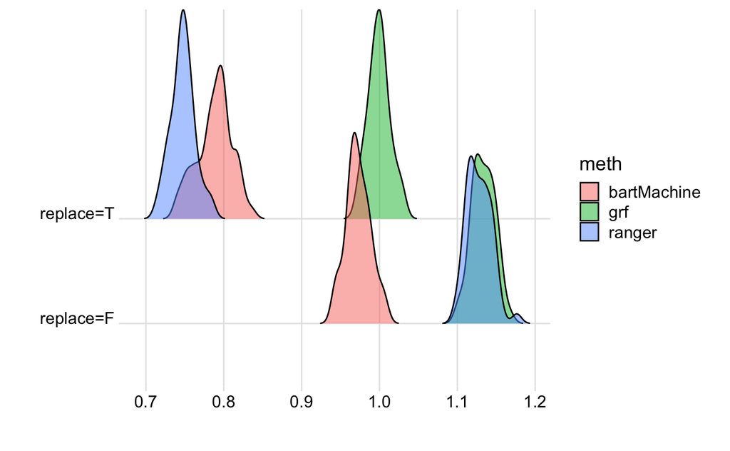

```r
perf.bs <- NULL
for(i in 1:50) {
  # replace = T
  inds <- sample(1:nrow(X),nrow(X),replace = T)
  rang.bsT <- ranger(Y ~., data = data.frame(X[inds,],Y = Y[inds]))
  bart.bsT <- bartMachine(X = data.frame(X[inds,]),y = Y[inds],verbose = F)
  grf.bsT <- regression_forest(X = X[inds,],Y = Y[inds])
  grf.bsT.err <- sqrt(mean((Y[inds] - predict(grf.bsT)$predictions)^2))

  # replace = F
  inds <- sample(1:nrow(X),round(nrow(X)*.6),replace = F)
  rang.bsF <- ranger(Y ~., data = data.frame(X[inds,],Y = Y[inds]))
  bart.bsF <- bartMachine(X = data.frame(X[inds,]),y = Y[inds],verbose = F)
  grf.bsF <- regression_forest(X = X[inds,],Y = Y[inds])
  grf.bsF.err <- sqrt(mean((Y[inds] - predict(grf.bsF)$predictions)^2))

  perf.bs <- bind_rows(perf.bs,
                       data.frame(err = c(sqrt(rang.bsT$prediction.error),
                                          sqrt(rang.bsF$prediction.error)),
                                  bsType = c("replace=T","replace=F"),
                                  meth = "ranger"),
                       data.frame(err = c(bart.bsT$rmse_train,bart.bsF$rmse_train),
                                  bsType = c("replace=T","replace=F"),
                                  meth = "bartMachine"),
                       data.frame(err = c(grf.bsT.err,grf.bsF.err),
                                  bsType = c("replace=T","replace=F"),
                                  meth = "grf"))
  #cat(i,"\n")
}

perf.bs %>%
  ggplot(aes(x = err,y = bsType,fill = meth)) +
  geom_density_ridges(scale = 2,rel_min_height = .001,alpha = .5) +
  theme_ridges() + ylab("") + xlab("")
```

There is a difference. However, it could due to 2 reasons: 1. the bootstrapped sample, $\hat{F}^*$, does not provide an approximation to the original emprical process $\hat{F}$, therfore, $\hat{F}^*$ is even far from the true distribution $F$. Or 2, it is just because for each model, you have less observations,hence lose information.

Now, I follow the pseudo-population procedure: replicating the sample 20 times, and sample the same number as the original sample (So 5% of the extended sample).

Note the idea of pseudo population bootstrap is: consider we have population size $N$, and our sample size is $n$. We extend our sample to $N$ by replicating our sample by $\lfloor \frac{N}{n} \rfloor$ times

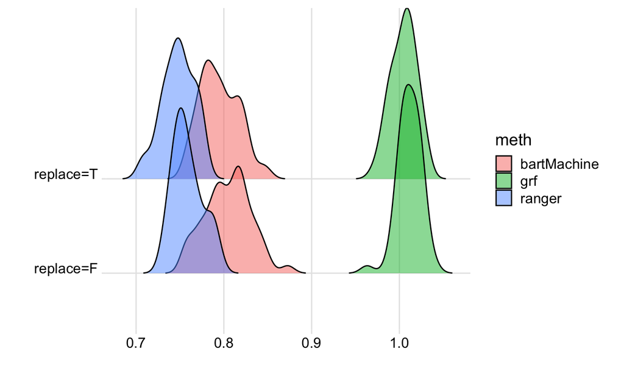

Note I try replicating 10 times before, it does not work well. But when I try 20 times, it works. Also, I didn’t consider the case that when $\frac{N}{n}$ is not an integer in which case we need to consider fill-in strategy (how to pick $s$ observation so that $n* \lfloor \frac{N}{n} \rfloor +s =N$).

There are some bootrap scheme I haven’t try. For example, bootstrap via reweighting, and bag of a little bootstrap. Nevertheless, I think they should be similar when $B\to \infty$.

## Out-bag Performance

Now the question is why grf has the worst in-sample performance. I guess it is because the honesty inferene here, so prevent overfitting. Now we can check out-of-bag performance by spliting the data into train set and test set first.

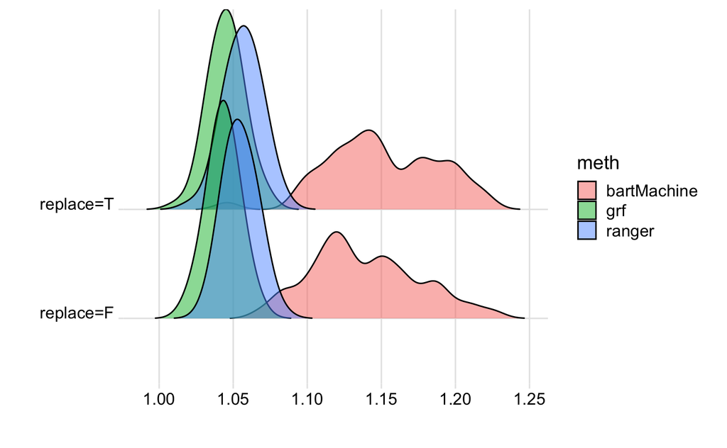